# Congressional Polarization and Potential Causes behind it: A Comprehensive Analysis

Bao Linh Hoang

`11-01-2023`

## 1. Introduction

This report delves into the intricate world of congressional polarization and its profound implications for policy making in the United States. As a prospective CRS Senior Analyst, my goal is to shed light on the evolving dynamics of polarization over time, exploring its consequences on legislative outcomes and the functioning of Congress. This investigation can be crucial for policymakers, scholars, and the public to better understand the current state of our nation’s political landscape and the challenges it presents.

## 2. Trends

### a. General trend of polarization over time

To begin, we investigate the trajectory of polarization using the “dw1” and “year” variables. As depicted in the line chart, there is a clear upward trend throughout the entire period. Notably, the graph displays a substantial increase starting around 1980, signifying a notable acceleration in polarization from that point onward.

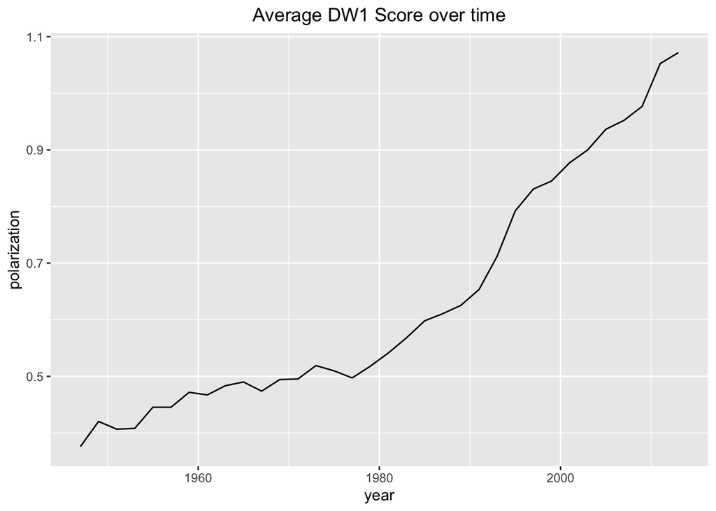

### b. Polarization over time by chamber and party

Next, we analyze the average “dw1” scores within distinct time intervals, examining them separately for the House and the Senate. When comparing the two major political parties in the graph, we observe that the House exhibits more pronounced polarization compared to the Senate. Specifically, Republicans in the House show a sharp increase above the 0.25 mark (indicating conservatism) since 1977. Similarly, Republican senators also lean towards the conservative side at the beginning of the period and surpass the 0.25 mark since 1977.

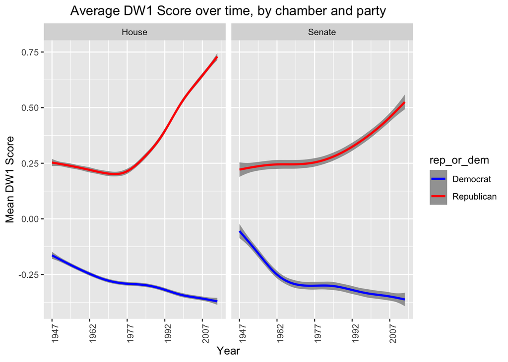

## 3. Causes

This study delves into the causes of member polarization in the United States Congress, offering an unconventional exploration of the ideological divisions that shape American politics. Using a diverse set of variables, such as demographic factors and party unity, we aim to construct a narrative supported by compelling visuals and robust statistical analyses. This investigation goes beyond conventional wisdom, striving to uncover hidden dynamics in American politics. By examining bivariate relationships and multivariate models, we seek to understand the forces driving polarization and assess variations between the House and Senate. While our findings may confirm or challenge established claims, every choice made in this exploration is thoughtfully discussed and defended, ensuring that our results withstand scrutiny and provide fresh insights into the complex world of member polarization.

### a. Party Unity

#### i. Visualization

First and foremost, we will analyze the party unity variable. The graph initially depicts a decline at the beginning of the period. However, an intriguing shift occurs around the year 1980, with the graph showing a significant upward trajectory from approximately 75 mark to nearly 95 by the end of the period. Notably, when we revisit the trends section in the first polarization-over-time graph, we observe a corresponding rise in party unity during the same period as the increase in polarization. This correlation suggests that party unity might be a contributing factor to polarization.

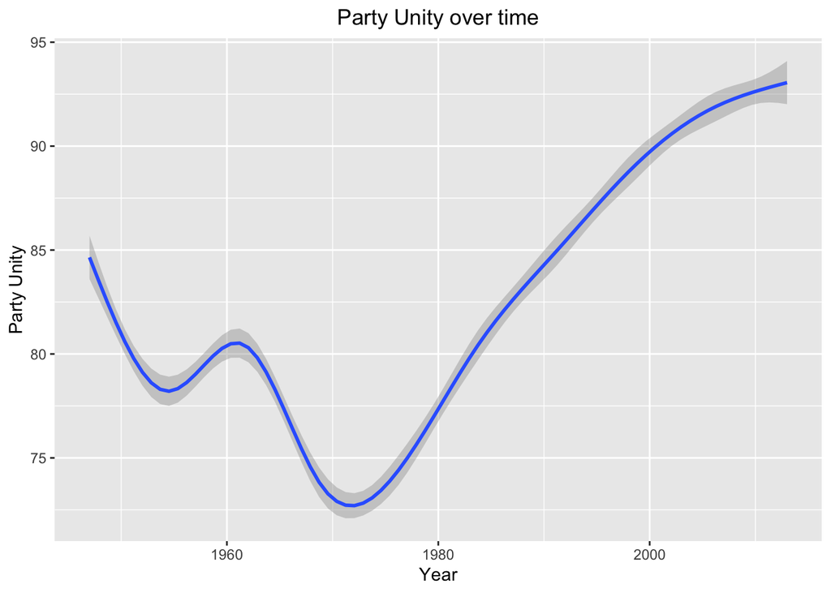

#### ii. Table

The table presents the results of a linear regression model assessing the relationship between dw1 and the independent variables ptyunity and rep_or_dem. This linear model can be represent by the equation: dw1 = -0.1506546 - 0.0016574 * ptyunity + 0.6595542 * rep_or_demRepublican. The model appears to be highly significant, and the coefficients for both independent variables are also significant, with the “Pr(>|t|)” value (the p-value) are both smaller than 0.05. This suggest a strong relationship between these variables and congressional ideology (dw1).

```
##
## Call:
## lm(formula = dw1 ~ ptyunity + rep_or_dem, data = house)
##
## Residuals:
##      Min       1Q   Median       3Q      Max
## -0.90617 -0.14048 -0.01993  0.12872  1.12130
##
## Coefficients:
##                        Estimate Std. Error t value Pr(>|t|)
## (Intercept)          -0.1506546  0.0089580  -16.82   <2e-16 ***
## ptyunity             -0.0016574  0.0001056  -15.70   <2e-16 ***
## rep_or_demRepublican  0.6595542  0.0034575  190.76   <2e-16 ***
## ---
## Signif. codes:  0 '***' 0.001 '**' 0.01 '*' 0.05 '.' 0.1 ' ' 1
##
## Residual standard error: 0.2095 on 14926 degrees of freedom
##   (18 observations deleted due to missingness)
## Multiple R-squared:  0.7093, Adjusted R-squared:  0.7092
## F-statistic: 1.821e+04 on 2 and 14926 DF,  p-value: < 2.2e-16
```

### b. Percentage of Latino’s population

#### i. Visualization

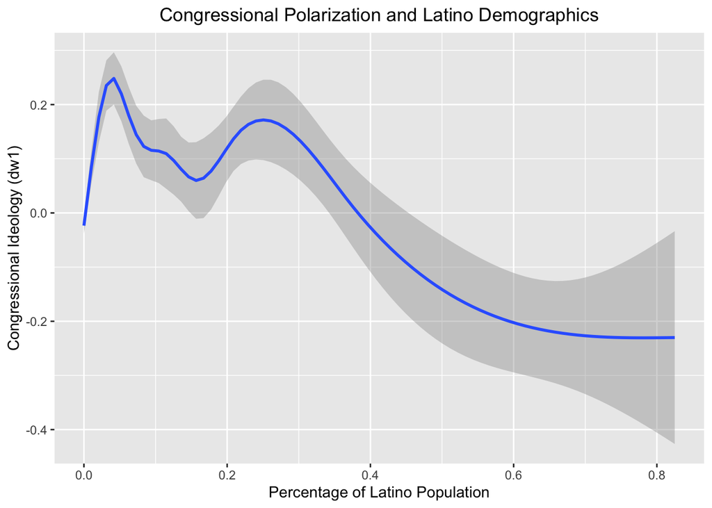

#### ii. Spearman test

The Spearman’s rank correlation test examines the relationship between two variables: the percentage of the Latino population (pctlatino) and congressional ideology scores (dw1). The test resulted in a Spearman’s rank correlation coefficient (rho) of approximately 0.0775, which is a positive correlation. This indicates a positive association between the percentage of Latino population and congressional ideology.

```
##
##  Spearman's rank correlation rho
##
## data:  congress_data$pctlatino and congress_data$dw1
## S = 7921288829, p-value = 2.214e-06
## alternative hypothesis: true rho is not equal to 0
## sample estimates:
##        rho
## 0.07749629
```

### c. Percentage of population over 65

#### i. Visualization

Thirdly, we examine the relationship between pctage65 and the dw1 variables. The graph reveals a noticeable pattern. In areas with a low percentage of residents aged 65 and above (ranging from 0.0 to 0.3), the graph displays fluctuations around the neutral point (0.0) on the dw1 score, indicating a relatively balanced ideological mix. However, as the percentage of elderly residents exceeds the 0.3 threshold, there is a distinct upward trend toward conservatism. For instance, when the percentage of elderly people reaches 0.4, the dw1 score hovers around 0.3, signifying a conservative leaning. This suggests that a higher proportion of elderly individuals may be a contributing factor to polarization, as these areas tend to exhibit more conservative ideologies.

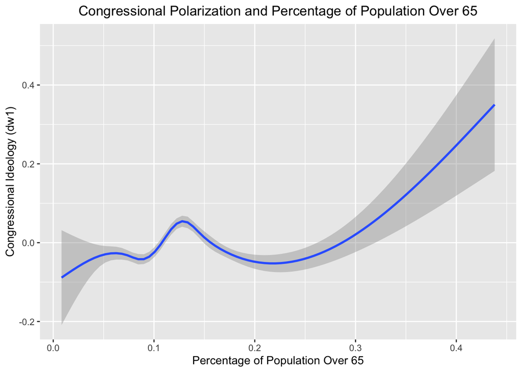

#### ii. Pearson Test

The Pearson’s product-moment correlation test assesses the relationship between two variables: the percentage of the population over 65 years old (pctage65) and congressional ideology scores (dw1). The test yielded a Pearson correlation coefficient (cor) of approximately 0.0229, which indicates a positive correlation. This suggests a positive association between the percentage of the population over 65 and congressional ideology.

The t-value is approximately 2.9115, and the degrees of freedom (df) are 16,173. The associated p-value is 0.003602, which is less than the commonly used significance level of 0.05. This means that the observed correlation is statistically significant, suggesting that there is a positive correlation between the percentage of the population over 65 and congressional ideology, specifically conservatism. The 95 percent confidence interval for the correlation ranges from approximately 0.0075 to 0.0383.

In summary, the test indicates a positive relationship between the percentage of the population over 65 and congressional ideology, with areas having a higher percentage of older residents tending to be associated with slightly more conservative ideology.

```
##
##  Pearson's product-moment correlation
##
## data:  congress_data$pctage65 and congress_data$dw1
## t = 2.9115, df = 16173, p-value = 0.003602
## alternative hypothesis: true correlation is not equal to 0
## 95 percent confidence interval:
##  0.007479727 0.038285656
## sample estimates:
##        cor
## 0.02288812
```

## 4. Conclusion

In conclusion, this analysis sheds light on some of the key factors contributing to congressional polarization. The examination of party unity, demographic diversity, the elderly population, and the influence of party affiliation has revealed intriguing insights into the dynamics of polarization.

Party unity stands out as a significant driver of polarization, with an upward trend since the 1980s. This suggests that a more cohesive party might be pushing its members towards more extreme positions.

Given more time and resources, exploring additional variables such as campaign finance, educational background, and regional influences could offer a more comprehensive understanding of polarization. Additionally, assessing the impact of historical events, economic factors, and the role of leadership on polarization would provide a deeper perspective.

It is crucial to acknowledge the limitations of this analysis, such as potential omitted variable bias and the complexity of human behavior. Interpretation should consider the multifaceted nature of polarization, as it might not be solely explained by the variables explored here.

As we reflect on the implications of polarization, it appears to be a logical consequence of various political and social factors. While it may contribute to legislative gridlock, it also reflects the diversity of perspectives in our democracy. It is essential for policymakers to address polarization constructively, focusing on finding common ground and fostering collaboration to overcome its potential drawbacks.